# Análise da Geração, Consumo e Consumidores

de Energia Elétrica no Brasil

2024-10-24

# Introdução

A energia elétrica é um pilar essencial para o desenvolvimento econômico e social de qualquer país e, no Brasil, não é diferente. Em um país de dimensões continentais, com uma população de mais de 212 milhões de pessoas e uma economia em constante transformação, o consumo de energia elétrica revela muito sobre as dinâmicas regionais e socioeconômicas. O objetivo deste relatório é analisar os padrões de consumo de energia elétrica no Brasil, destacando as variações e as tendências ao longo do tempo da matriz energética nacional.

Esse estudo abrange os dados recentes de geração e consumo de energia e consumidores conectados à rede elétrica, com um foco especial nas macrorregiões e nas categorias que mais consomem. Também abordaremos os impactos de políticas de eficiência energética e o papel crescente das energias renováveis, como a solar e a eólica.

## Objetivo

O objetivo principal é compreender como o consumo de energia no Brasil está distribuído, quais fatores impulsionam esse consumo, e como o país pode enfrentar os desafios de uma demanda crescente, mantendo ao mesmo tempo a sustentabilidade ambiental e a segurança energética. Portanto, este relatório apresenta uma análise detalhada do consumo de energia elétrica no Brasil, baseada em dados históricos e setoriais. Utilizaremos gráficos e pramagação em R para ilustrar as principais tendências e comparações entre regiões e setores.

## Pacotes Utilizados

| Package | Version | Citation |
| --- | --- | --- |
| base | 4.4.1 | R Core Team (2024) |
| basedosdados | 0.2.2 | Cavalcante, Herszenhut, and Dornelles (2023) |
| bslib | 0.8.0 | Sievert, Cheng, and Aden-Buie (2024) |
| fabletools | 0.5.0 | O’Hara-Wild, Hyndman, and Wang (2024) |
| fpp3 | 1.0.1 | Hyndman (2024) |
| geobr | 1.9.1 | Pereira and Goncalves (2024) |
| gganimate | 1.0.9 | Pedersen and Robinson (2024) |
| ggthemes | 5.1.0 | Arnold (2024) |
| kableExtra | 1.4.0 | Zhu (2024) |
| knitr | 1.48 | Xie (2014); Xie (2015); Xie (2024) |
| patchwork | 1.3.0 | Pedersen (2024) |
| prettydoc | 0.4.1 | Qiu (2021) |
| rmarkdown | 2.28 | Xie, Allaire, and Grolemund (2018); Xie, Dervieux, and Riederer (2020); Allaire et al. (2024) |
| scales | 1.3.0 | Wickham, Pedersen, and Seidel (2023) |
| tidyverse | 2.0.0 | Wickham et al. (2019) |
| tsibble | 1.1.5 | Wang, Cook, and Hyndman (2020) |
| RStudio | 2023.6.1.524 | Posit team (2023) |

### Dados Utilizados

```r
# --- Consumo ---

# Baixar o arquivo temporariamente
url <- "https://www.epe.gov.br/sites-pt/publicacoes-dados-abertos/dados-abertos/Documents/Dados_abertos_Consumo_Mensal.xlsx"
temp_file <- base::tempfile(fileext = ".xlsx")

# Download do arquivo
httr::GET(url, httr::write_disk(temp_file, overwrite = TRUE))
```

```r
# Ler o arquivo Excel
consumo <- readxl::read_excel(temp_file, sheet = 2)
setor <- readxl::read_excel(temp_file, sheet = 3)

# --- Estados ---
estados <- geobr::read_state()
```

# Padrões de Consumo ao Longo do Tempo

Nos últimos 20 anos, o consumo de energia elétrica no Brasil tem mostrado uma tendência de crescimento consistente, embora marcada por alguns eventos críticos que geraram flutuações. Essa trajetória de longo prazo reflete o desenvolvimento econômico do país, a expansão populacional e o aumento da urbanização, além de uma maior eletrificação dos setores produtivos e das residências. No entanto, ao longo desse período, crises econômicas e políticas, como a recessão de 2014-2016 e os efeitos da pandemia de COVID-19 em 2020, geraram quedas pontuais no consumo, destacando a sensibilidade do setor energético às condições econômicas e sociais.

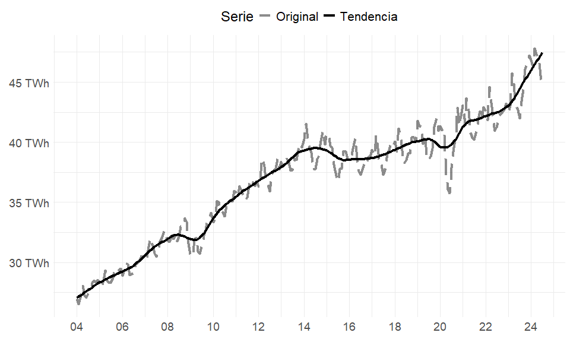

```r
### Consumo Total ####
consumo %>%
  dplyr::summarise(Consumo = sum(Consumo),
                   .by = c(DataExcel)) %>%
  dplyr::mutate(DataExcel = tsibble::yearmonth(DataExcel)) %>%
  tsibble::as_tsibble(index = DataExcel) %>%
  fabletools::model(STL(Consumo)) %>%
  fabletools::components() %>%
  dplyr::mutate(DataExcel = as.Date(DataExcel)) %>%
  ggplot() +
  geom_line(aes(x = DataExcel,
                y = Consumo,
                linetype = 'Original'),
            linewidth = 1.45,
            alpha = 0.45) +
  geom_line(aes(x = DataExcel,
                y = trend,
                linetype = 'Tendencia'),
            linewidth = 1.45) +
  labs(x = element_blank(),
       y = element_blank(),
       linetype = 'Serie',
       color = 'Setor') +
  scale_x_date(date_breaks = '2 year',
               date_labels = '%y') +
  scale_y_continuous(labels = scales::number_format(suffix = ' TWh',
                                                    scale = 1/1e6)) +
  scale_linetype_manual(values = c('longdash', 'solid')) +
  theme_minimal() +
  theme(text = element_text(size = 18),
        legend.position = 'top',
        legend.text = element_text(size=16))
```

## Entre o Crescimento e as Crises:

Entre 2004 e 2014, o gráfico mostra um aumento constante no consumo de energia, atingindo um patamar de aproximadamente 40 TWh. Esse período coincide com o crescimento econômico sustentado no Brasil, quando a demanda por eletricidade acompanhou o aumento da produção industrial e o consumo residencial mais intensivo, impulsionado pela maior disponibilidade de crédito, aumento da renda e popularização de equipamentos eletroeletrônicos.

No entanto, a partir de 2015, observa-se uma estagnação e, em alguns casos, uma leve redução no consumo de energia. Isso pode ser diretamente associado à recessão econômica que o país enfrentou, durante a qual a desaceleração industrial e a retração do consumo das famílias impactaram o uso de eletricidade. Este período de desaceleração é claramente representado no gráfico pela quebra da tendência de crescimento.

Já a pandemia de COVID-19, em 2020, provocou uma nova contração na demanda de energia, conforme a atividade econômica foi interrompida, sobretudo nos setores industrial e de serviços. A interrupção temporária das atividades de fábricas, comércios e serviços resultou em uma queda abrupta no consumo de eletricidade. Entretanto, o impacto da pandemia não foi duradouro, como demonstrado pela recuperação rápida observada em 2021, quando o consumo de energia elétrica volta a crescer.